# BRFSS Exploratory Data Analysis

BRFSS exploratory data analysis

The goal of this analysis is to walk through the process to create EDA for BRFSS

- BRFSS Data Set
- Research Topics
- Understanding Confounders and Web of Causation
- Data Dictionary
- Table 1 with all the descriptive statistics
- Research Questions
- Visualizations

## BRFSS Data Set

The differences between BRFSS and NHANES. First, while the CDC organizes the BRFSS and provides supports to states doing the BRFSS, the data collection is actually run at the state level. Next, instead of running around neighborhoods in a MEC, the BRFSS does anonymous phone surveys by simply randomly generating phone numbers, calling them, and doing the survey. Admittedly, BRFSS was a little late to the gate in getting cell phone numbers into the sampling frame, but they worked very hard on it. And now their sampling appears to be fairly robust. Also, they compile the dataset annually instead of every two years like NHANES. Next, there is this concept in the BRFSS of core questions and questions from modules. Because the feds organize the BRFSS, there are certain questions they insist are asked pretty much the same way every year as these are part of the core questions every year that states are obligated to ask. This way, the feds can trend rates of, say, smoking. But states are the ones who are actually doing the survey. Therefore, they have their own needs. And to accommodate those, they use different sets of validated BRFSS modules each year so they can keep tabs on their state-specific problems. For example, some states have cities with smog problems, and those states may choose to include the asthma / adult asthma history module one year. Or states experiencing a spike in racially-motivated violence might choose to include the reactions to race module that year. The answers to the core questions are available publicly in a huge dataset you can download. Some researchers don’t trust the BRFSS because people are expected to self-report conditions such as having diabetes. Unlike in NHANES, there is a lack of clinical confirmation of self-reported conditions in other metrics in BRFSS. But many analyses have shown that the BRFSS is pretty accurate. Some, such as myself, believe that the reduced selection bias in a large sample associated with BRFSS helps overcome the possible misclassification problems introduced by the phone versus in-person survey and that these biases are preferable to the more severe selection bias present in the smaller NHANES sample. But there is no right answer, whatever floats your boat. So some see the main drawback to the BRFSS is a lack of clinical confirmation due to the nature of it being a phone survey. There is another drawback. Unfortunately, only the results of the core questions are available publicly with documentation. If you want state module questions, you’ll have to contact that state’s public health department and see if they’re willing to share their module data with you. So now, I’m done with our quick review of US risk factors surveillance systems: the NHANES and the BRFSS.

## Research Questions

Relevance : Perceived Insufficient Rest or Sleep among Veterans:Behavioral Risk Factor Surveillance System 2009  
https://www.ncbi.nlm.nih.gov/pmc/articles/PMC3659378/pdf/jcsm.9.6.577.pdf

Research Questions : The purpose of this study is to investigate whether self-reported insufficient rest or sleep varies in relation to Veteran status and to identify high-risk groups of Veterans

Subpopulation : Stratified Veterans from Survey data with two stratas - newly transitioned veterans and long-term veterans

Exposure : Independent variables : Something you think causes, former is associated with disease or outcome * Independent Categorical Variable : Alcohol Consumption

Outcome : Dependent variables : Something you think is affected by exposure * Dependent Continuous Variable : Sleep Per Night

- Independent Categorical Variable : Alcohol Consumption
- Dependent Categorical Binary Variable : Asthma

So our goal is to identify confounding variables between exposure, alcohol drinking, and our outcomes, which are sleep duration and asthma, which are not on the causal pathway between the exposure and the outcome.

## Understanding Confounders and Web of Causation

Independent (exposure) variable : Alcohol Consumption Dependent (outcome) variable : Insufficient Sleep Candidate Confounders : Age, Sex, Race/Ethinicity, Marital Status, Highest Education Level, Physical Activity Status, Highest Education Level, Self-Reported Generated Health, Obesity, Smoking Status, Having Health Insurance Candidate Confounder not available in BRFSS : Sleep Apnea

We also want to load packages that have functions in them we want to use. For this particular analysis we will only need the `dplyr` package, but for your project you will also likely need other packages as well, e.g. `ggplot2`.

```r
library(knitr)
library(pander)
library(ggplot2)
library(colorspace)
library(tidyr)
library(dplyr)
library(questionr)
library(foreign)
library(MASS)
library(printr)
library(expss)
#library(dataMeta) #Create a Data Dictionary
opts_chunk$set(echo = TRUE,fig.align='center')
```

### Read in the data

Native Variables : * Veteran Status : Have you ever served on active duty in the United States Armed Forces, either in the regular military or in a National Guard or military reserve unit? (Active duty does not include training for the Reserves or National Guard, but DOES include activation, for example, for the Persian Gulf War.)

VETERAN3 Description 1 Yes 2 No 7 Don’t Know 9 Refused . Blank

- Alcohol consumption : During the past 30 days, how many days per week or per month did you have at least one drink of any alcoholic beverage such as beer, wine, a malt beverage or liquor?
- Sleep duration : On average, how many hours of sleep do you get in 24-hour period?
- Asthma status : Ever told you had Asthma ?

## Build Data Dictionary

```r
setwd("/Users/chetana/Documents/Coursera/Duke - Statistics with R/Projects/Course1/data")
analytic <- read.csv(file = "analytics.csv", header=TRUE, sep=",")



BRFSSVarList <- c("VETERAN3",
                  "ALCDAY5",
                  "SLEPTIM1",
                  "ASTHMA3",
                  "X_AGE_G",
                  "SMOKE100",
                  "SMOKDAY2",
                  "SEX",
                  "X_HISPANC",
                  "X_MRACE1",
                  "MARITAL",
                  "GENHLTH",
                  "HLTHPLN1",
                  "EDUCA",
                  "INCOME2",
                  "X_BMI5CAT",
                  "EXERANY2")

#subset by varlist
```

## Required Data Processing Function

```
  The following function is used in the exploratory data analysis to reduce the brfss2013 data to just those observations that had a value for each of the variables under consideration - allprep:
```

```r
allprep <- function(...) {
    study <- analytic %>%
        dplyr::select(...)

    return(study[complete.cases(study),])
}
ASTHMA4_f <- factor(analytic$ASTHMA4, labels = c("No Asthma", "Yes Asthma"))
analytic$ASTHMA4_f <- factor(analytic$ASTHMA4, labels = c("No Asthma", "Yes Asthma"))

ALCGRP_f <- factor(analytic$ALCGRP, labels = c("No Drinks in past 30 days", "Drink Monthly", "Drink Weekly"))
analytic$ALCGRP_f <-ALCGRP_f

X_SMOKER3_f <- factor(analytic$X_SMOKER3, labels = c("Smokes every day","Smokes some days","Former Smoker","Never Smoked","Unknown"))
analytic$X_SMOKER3_f <-X_SMOKER3_f

X_AGE_G_f <- factor(analytic$X_AGE_G, labels = c(" Age 18 to 24","Age 25 to 34","Age 35 to 44","Age 45 to 54","Age 55 to 64","Age 65 or older"))
analytic$X_AGE_G_f <-X_AGE_G_f

nrow(analytic$X_SMOKER3)
```

## Research Question 1:

JCSM (URL linked above) concludes that veteran’s sleep time is insufficient and needs to be targeted to improve, this research is to identify all the variables associated with sleep time and indentifying if they are corelated keeping in mind that corelation does not imply causation. Is there any association with ASTHMA and Alcohol consumption, alcohol consumption and sleep time. Since ASTHMA is a confounding outcome variable, here we are trying to associate Alcohol consumption to Asthma.

### Exploratory Data Analysis for Question 1 :

#### Univariate Analysis

Analysis : Distribution of ASTHMA (variable : ASTHMA4) categorical variable

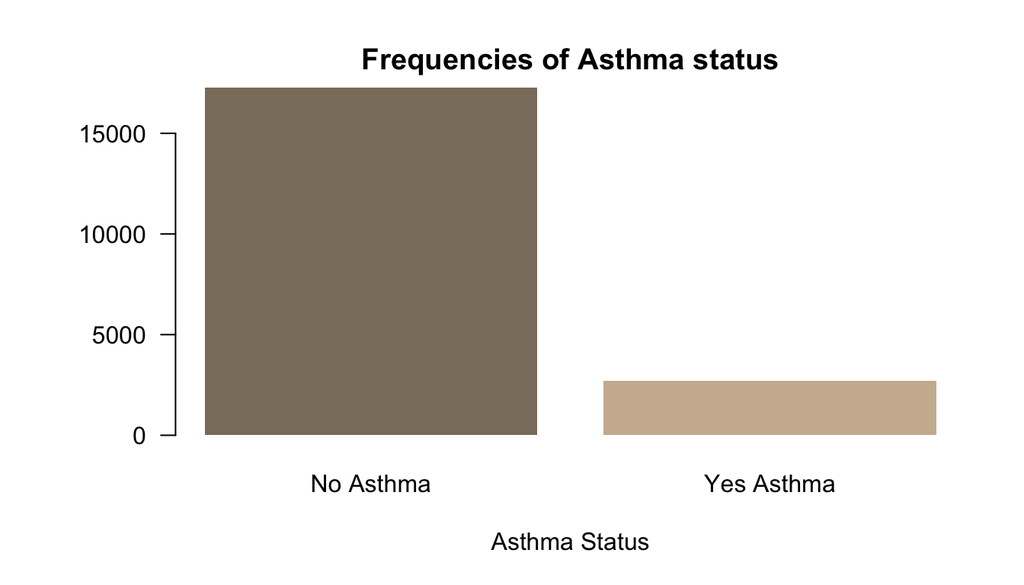

```r
analytic = apply_labels(analytic,
                      ASTHMA4 = "Asthma Status"
)


VET_ASTHMA<-table(ASTHMA4_f)


# Customize the chart
par(oma = c(1, 1, 1, 1))  # Sets outside margins: b, l, t, r
par(mar = c(4, 5, 2, 1))  # Sets plot margins
barplot(table(ASTHMA4_f[order(ASTHMA4_f)]),
        las    = 1,  # las gives orientation of axis labels
        col    = c("bisque4","bisque3"),
        border = NA,  # No borders on bars
        main   = "Frequencies of Asthma status",  # \n = line break
        xlab   = "Asthma Status")
```

```r
AsthmaAlcFreq <- table(analytic$ASTHMA4, analytic$ALCGRP)
prop.table(AsthmaAlcFreq)*100
```

| / | 1 | 2 | 3 |
| --- | --- | --- | --- |
| 0 | 43.464101 | 31.364297 | 11.673932 |
| 1 | 7.565509 | 4.358936 | 1.573225 |

```r
VET_ALC_ASTH_SUM <- analytic %>%
    group_by(ALCGRP) %>%
    summarize(n = n(), Q1 = quantile(ASTHMA4, 0.25), MEAN = mean(ASTHMA4), MEDIAN = median(ASTHMA4),Q3 = quantile(ASTHMA4, 0.75), IQR = IQR(ASTHMA4), STDEV = sd(ASTHMA4)) %>%
    mutate(asthmafreq = n*100/sum(n)) %>%
    mutate(SKEW = ifelse(MEAN > MEDIAN, "RIGHT", "LEFT"))

VET_ALC_ASTH_SUM
```

| ALCGRP | n | Q1 | MEAN | MEDIAN | Q3 | IQR | STDEV | asthmafreq | SKEW |
| --- | --- | --- | --- | --- | --- | --- | --- | --- | --- |
| 1 | 10185 | 0 | 0.1482572 | 0 | 0 | 0 | 0.3553722 | 51.02961 | RIGHT |
| 2 | 7130 | 0 | 0.1220196 | 0 | 0 | 0 | 0.3273314 | 35.72323 | RIGHT |
| 3 | 2644 | 0 | 0.1187595 | 0 | 0 | 0 | 0.3235664 | 13.24716 | RIGHT |

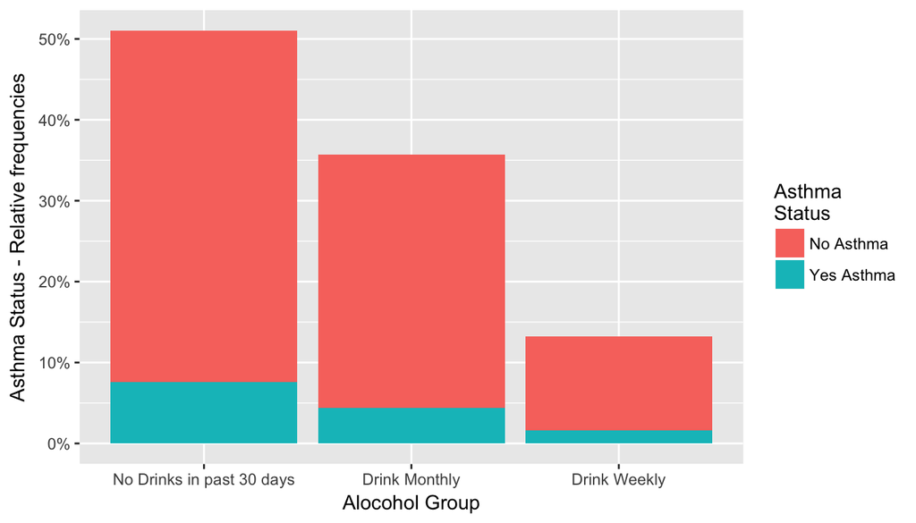

```r
  ggplot(analytic, aes(analytic$ALCGRP_f, fill=analytic$ASTHMA4_f)) +
  geom_bar(aes(y = (..count..)/sum(..count..),fill=analytic$ASTHMA4_f)) +
  scale_y_continuous(labels=scales::percent) +
  ylab("Asthma Status - Relative frequencies") +
  xlab("Alocohol Group") +
  scale_fill_discrete(name="Asthma\nStatus")
```

## Univariate Analysis with outcome variable SLEEP TIME (variable: SLEPTIM2) which is a continuous variable

```r
VET_SLEPTIM <- analytic %>%
    summarize(Q1 = quantile(SLEPTIM2, 0.25), MEAN = mean(SLEPTIM2), MEDIAN = median(SLEPTIM2),Q3 = quantile(SLEPTIM2, 0.75), IQR = IQR(SLEPTIM2), STDEV = sd(SLEPTIM2)) %>%
    mutate(SKEW = ifelse(MEAN > MEDIAN, "RIGHT", "LEFT"))
VET_SLEPTIM
```

| Q1 | MEAN | MEDIAN | Q3 | IQR | STDEV | SKEW |
| --- | --- | --- | --- | --- | --- | --- |
| 6 | 6.989779 | 7 | 8 | 2 | 1.742289 | LEFT |

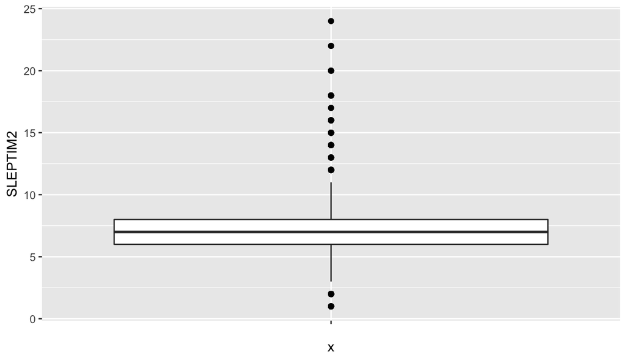

```r
ggplot(analytic, aes(x = "", y=SLEPTIM2)) +
          geom_boxplot(outlier.colour="black", outlier.shape=16,
             outlier.size=2, notch=FALSE)
```

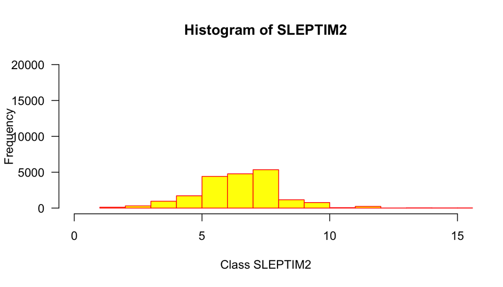

```r
hist(analytic$SLEPTIM2,
     main = "Histogram of SLEPTIM2",
     xlab = "Class SLEPTIM2",
     ylab = "Frequency",
     xlim=c(0,15),
     ylim=c(0,20000),
     border = "red",
     col= "yellow",
     las = 1,
     breaks = 24)
```

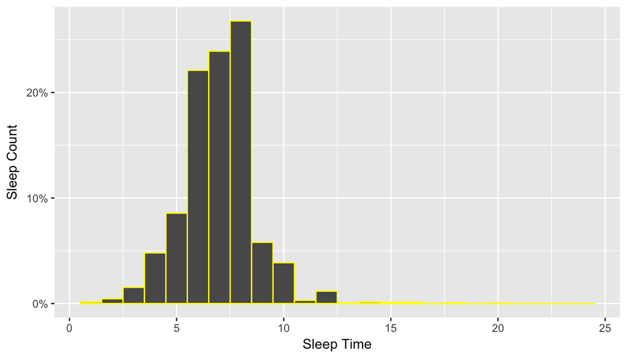

```r
ggplot(analytic, aes(SLEPTIM2)) +
          geom_histogram(aes(y = (..count..)/sum(..count..)), binwidth = 1,color ="yellow") +
          scale_y_continuous(labels=scales::percent) +
          ylab("Sleep Count") +
          xlab("Sleep Time") +
          scale_fill_discrete(name="")
```

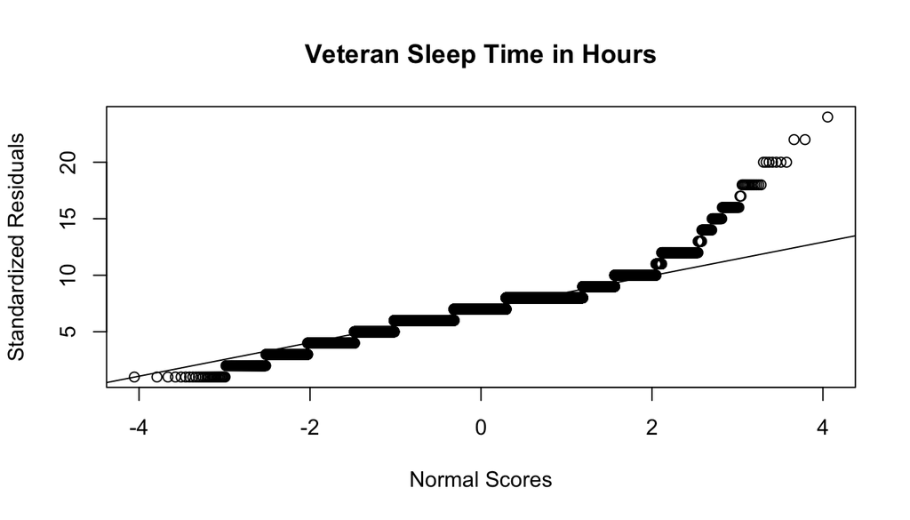

```
## logical(0)
```

```r
# Normal Distribution Plot
qqnorm(analytic$SLEPTIM2, ylab="Standardized Residuals", xlab="Normal Scores",main="Veteran Sleep Time in Hours") > qqline(analytic$SLEPTIM2)
```

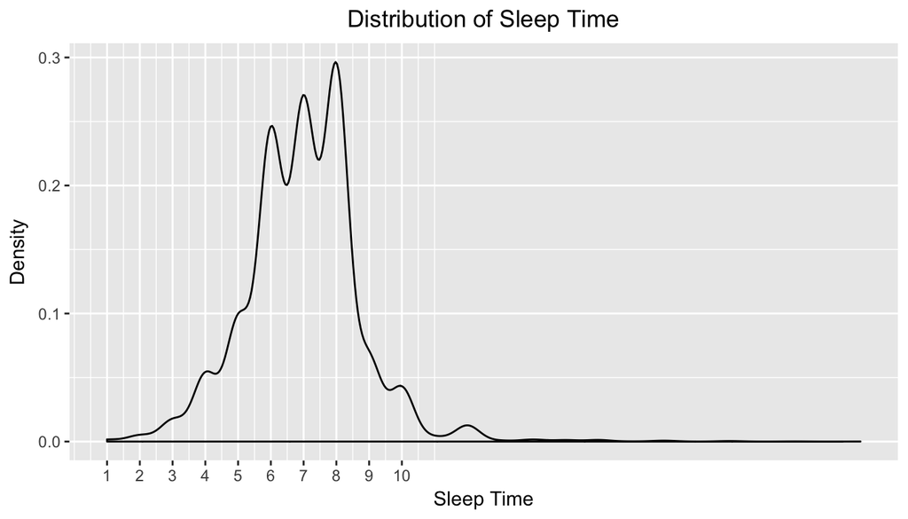

```r
ggplot(analytic, aes(x = SLEPTIM2)) +
    geom_density(adjust = 2) +
    scale_color_manual(values = rev(heat_hcl(6, h = c(20,-80), l = c(75,40), c =c(40,80), power = 1))) +
    scale_x_continuous(breaks = c(1:10)) +
    labs(title = "Distribution of Sleep Time", y = "Density", x = "Sleep Time", col = "") +
    theme(plot.title = element_text(hjust = 0.5))
```

## BIVARIATE ANALYSIS : Dstribution between sleep time and alcohol groups (continuouse variable : SLEEPTIM2 and categorical variable: ALGRP)

```r
SLEEP_ALC_SUM <- analytic %>%
    group_by(ALCGRP_f) %>%
    summarize(Q1 = quantile(SLEPTIM2, 0.25), MEAN = mean(SLEPTIM2), MEDIAN = median(SLEPTIM2),Q3 = quantile(SLEPTIM2, 0.75), IQR = IQR(SLEPTIM2), STDEV = sd(SLEPTIM2)) %>%
    mutate(SKEW = ifelse(MEAN > MEDIAN, "RIGHT", "LEFT"))
                                                                                                                SLEEP_ALC_SUM
```

| ALCGRP_f | Q1 | MEAN | MEDIAN | Q3 | IQR | STDEV | SKEW |
| --- | --- | --- | --- | --- | --- | --- | --- |
| No Drinks in past 30 days | 6 | 7.001080 | 7 | 8 | 2 | 1.892251 | RIGHT |
| Drink Monthly | 6 | 6.980645 | 7 | 8 | 2 | 1.594339 | LEFT |
| Drink Weekly | 6 | 6.970878 | 7 | 8 | 2 | 1.506042 | LEFT |

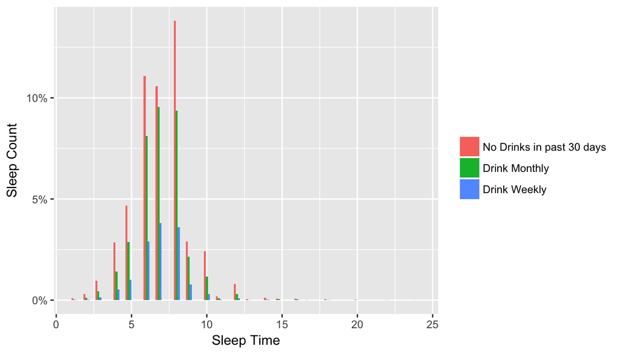

```r
ggplot(analytic, aes(SLEPTIM2, fill(ALCGRP_f))) +
          geom_histogram(aes(y = (..count..)/sum(..count..),fill=ALCGRP_f), binwidth = 0.4, position="dodge") +
          scale_y_continuous(labels=scales::percent) +
          ylab("Sleep Count") +
          xlab("Sleep Time") +
          scale_fill_discrete(name="")
```

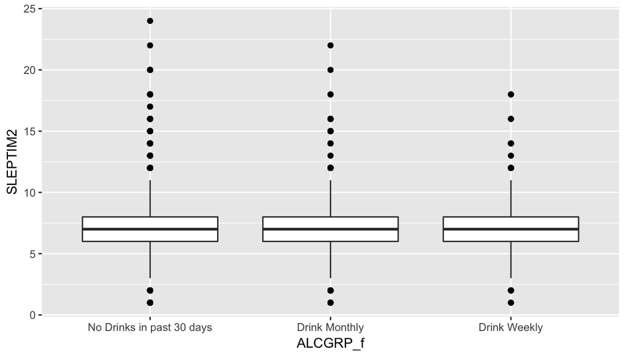

```r
ggplot(analytic, aes(x = ALCGRP_f, y=SLEPTIM2)) +
          geom_boxplot(outlier.colour="black", outlier.shape=16,
             outlier.size=2, notch=FALSE)
```

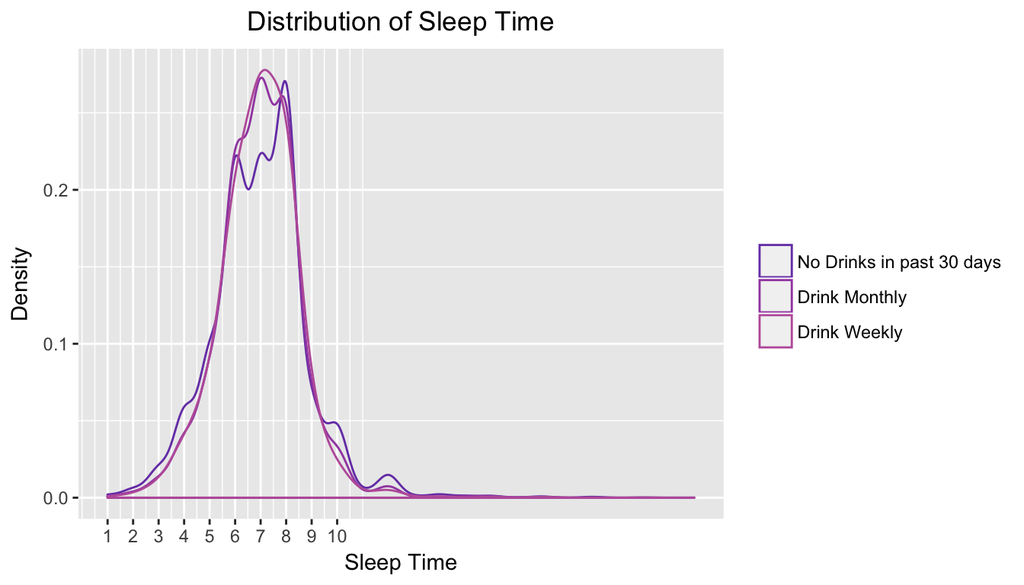

```r
ggplot(analytic, aes(x = SLEPTIM2, color = ALCGRP_f)) +
    geom_density(adjust = 2) +
    scale_color_manual(values = rev(heat_hcl(6, h = c(20,-80), l = c(75,40), c =c(40,80), power = 1))) +
    scale_x_continuous(breaks = c(1:10)) +
    labs(title = "Distribution of Sleep Time", y = "Density", x = "Sleep Time", col = "") +
    theme(plot.title = element_text(hjust = 0.5))
```

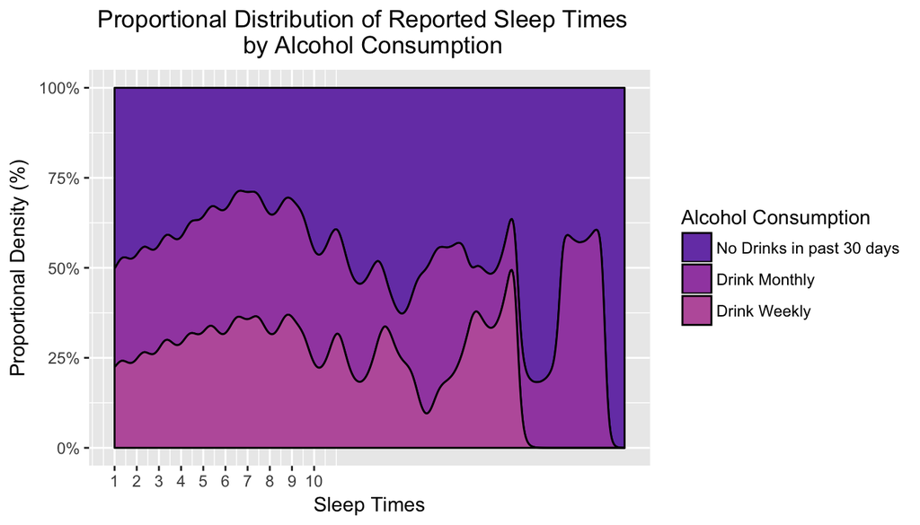

```r
ggplot(analytic, aes(x = SLEPTIM2, fill = ALCGRP_f)) +
    geom_density(position = "fill", adjust =2) +
    scale_fill_manual(values = rev(heat_hcl(6, h = c(20,-80), l = c(75,40), c =c(40,80), power = 1))) +
    scale_x_continuous(breaks = c(1:10)) +
    scale_y_continuous(labels = c("0%", "25%", "50%", "75%", "100%")) +
    labs(title = "Proportional Distribution of Reported Sleep Times  \n by Alcohol Consumption", y = "Proportional Density (%)", x = "Sleep Times", fill = "Alcohol Consumption") +
    theme(plot.title = element_text(hjust = 0.5))
```

### SUMMARY : In this research question, the main goal was to identify an association with sleep time and alcohol consumption. In brief, there does not appear a strong corelation between the two variables. To justify this, lets take a look at the box plots, the medians are the same and the whiskers in the plot doesn’t show any difference in the variability of data. The 50% with IQR = 2 indicates that most sleep times in the IQR are closer to the median and their sleep times range between 6-8 for all types of alcohol consumptions.The density plots for all the three categories have similar densities again indicating low corerelation between the variables.

## Research Question 2:

Are Veteran’s smoking habits and their age group associated with the number of days they reported where their physical health was not good?

### Exploratory Data Analysis for Question 2

To determine if there is an association between smoking habits and the number of days where physical health was not good, the summary statistics for measures of center and measures of the spread were determined. The skew of the data was also determined by comparing the mean and median - SMKR_AGE_HLTH_SUM:

```r
SMKR_AGE_HLTH <- allprep(X_SMOKER3_f,X_AGE_G_f, PHYSHLTH)

SMKR_AGE_HLTH_SUM <- SMKR_AGE_HLTH %>%
    group_by(X_AGE_G_f, X_SMOKER3_f) %>%
    filter(X_SMOKER3_f != "Unknown") %>%
    summarize(Q1 = quantile(PHYSHLTH, 0.25), MEAN = mean(PHYSHLTH), MEDIAN = median(PHYSHLTH),Q3 = quantile(PHYSHLTH, 0.75), IQR = IQR(PHYSHLTH), STDEV = sd(PHYSHLTH)) %>%
    mutate(SKEW = ifelse(MEAN > MEDIAN, "RIGHT", "LEFT")) %>%
    arrange(desc(MEAN))
SMKR_AGE_HLTH_SUM
```

```
## # A tibble: 24 x 9
## # Groups:   X_AGE_G_f [6]
##    X_AGE_G_f       X_SMOKER3_f     Q1  MEAN MEDIAN    Q3   IQR STDEV SKEW
##    <fct>           <fct>        <dbl> <dbl>  <dbl> <dbl> <dbl> <dbl> <chr>
##  1 Age 55 to 64    Smokes some…    6.  18.5    20.  30.0  24.0  11.5 LEFT
##  2 Age 55 to 64    Smokes ever…    4.  16.4    15.  30.0  26.0  11.9 RIGHT
##  3 Age 65 or older Smokes ever…    3.  16.1    15.  30.0  27.0  12.2 RIGHT
##  4 Age 65 or older Smokes some…    4.  15.3    13.  30.0  26.0  11.8 RIGHT
##  5 Age 55 to 64    Former Smok…    3.  15.0    10.  30.0  27.0  12.0 RIGHT
##  6 Age 45 to 54    Smokes ever…    3.  14.6    10.  30.0  27.0  11.8 RIGHT
##  7 Age 65 or older Former Smok…    3.  14.1    10.  30.0  27.0  11.7 RIGHT
##  8 Age 45 to 54    Smokes some…    3.  13.9    10.  30.0  27.0  11.8 RIGHT
##  9 Age 65 or older Never Smoked    3.  13.0     7.  30.0  27.0  11.5 RIGHT
## 10 " Age 18 to 24" Smokes ever…    2.  12.9     8.  28.2  26.2  11.9 RIGHT
## # ... with 14 more rows
```

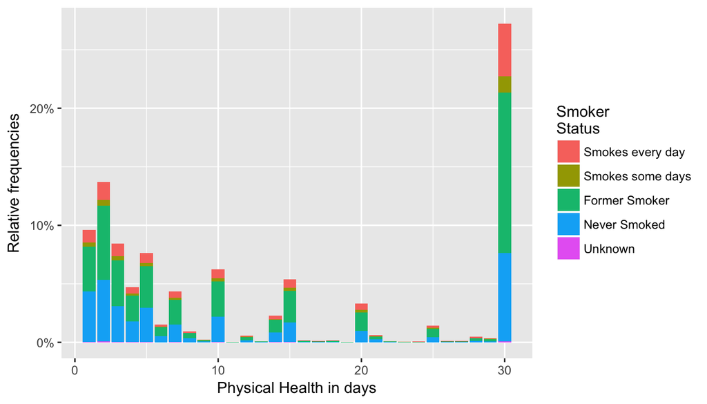

```r
sum2 <- analytic %>%
    group_by(PHYSHLTH) %>%
    summarize(n = n())
total <- sum(sum2$n)
sum2 <- sum2 %>% mutate(`% of total` = round(n/total*100,digits=1))

ggplot(analytic, aes(PHYSHLTH, fill=X_SMOKER3_f)) +
          geom_bar(aes(y = (..count..)/sum(..count..),fill=X_SMOKER3_f)) +
          scale_y_continuous(labels=scales::percent) +
          ylab("Relative frequencies") +
          xlab("Physical Health in days") +
          scale_fill_discrete(name="Smoker\nStatus")
```

The %total for physical health 30 days is considerably high and the data is heavily right skewed

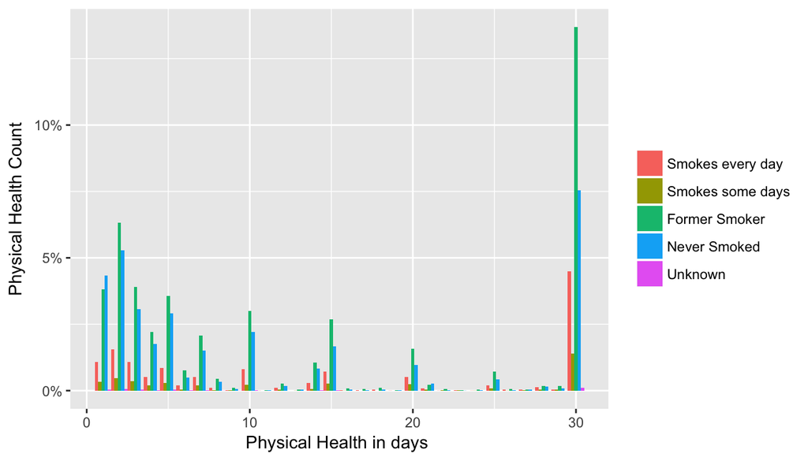

```r
ggplot(analytic, aes(PHYSHLTH, fill(X_SMOKER3_f))) +
          geom_histogram(aes(y = (..count..)/sum(..count..),fill=X_SMOKER3_f), binwidth = 1, position="dodge") +
          scale_y_continuous(labels=scales::percent) +
          ylab("Physical Health Count") +
          xlab("Physical Health in days ") +
          scale_fill_discrete(name="")
```

```
  These measures suggest some association between whether a person smokes and how many days of poor physical health they have during the month. Current smokers tend to have higher number of poor physical health days. In addition, the measures indicate some association between a respondent’s age and how many days of poor physical health they may have during month. Older age groups tend to have a higher number of poor physical health days.
```

[figure not shown]

```r
ggplot(analytic, aes(x = PHYSHLTH, color = X_SMOKER3_f)) +
    geom_density(adjust = 2) +
    scale_color_manual(values = rev(heat_hcl(6, h = c(20,-80), l = c(75,40), c =c(40,80), power = 1))) +
    scale_x_continuous(breaks = c(1:10)) +
    labs(title = "Distribution of Sleep Time", y = "Density", x = "Sleep Time", col = "") +
    theme(plot.title = element_text(hjust = 0.5))
```

## Summary

```
  Both the associations and the large spread and overlap in the data can be visualized with multiple boxplots:
```

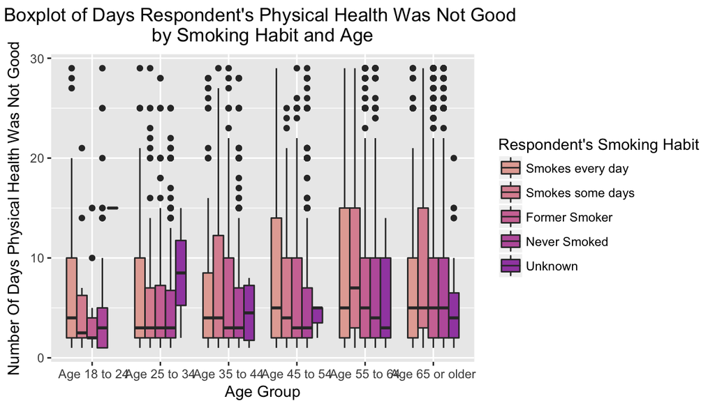

```r
no0_dat3 <- analytic %>% filter(PHYSHLTH !=30 )
ggplot(no0_dat3, aes(x = X_AGE_G_f, y = PHYSHLTH, fill = X_SMOKER3_f)) +
    geom_boxplot() +
    scale_fill_manual(values = heat_hcl(6, h = c(20,-80), l = c(75,40), c =c(40,80), power = 1)) +
    labs(title = "Boxplot of Days Respondent's Physical Health Was Not Good \n by Smoking Habit and Age ", fill = "Respondent's Smoking Habit",x = "Age Group", y = "Number Of Days Physical Health Was Not Good") +
    theme(plot.title = element_text(hjust = 0.5))
```

##Summary

```
  These boxplots display a version of the same information as the table above, except the mean and sd values are not plotted. The boxplots give a sense of the large IQR or spread in the data, especially for the older age groups indicating that the distribution of days with poor physical health ranges over almost all the possible options from 1-30 in these cases. The IQR also shows how some of these categories have large overlaps in their distribution, which reduces the strength of any association in the data as this means some of the distributions are not significantly distinct. In addition, the medians generally show the decreasing number of poor physical health days both as one is younger and does not smoke.
```

## Research Question 3:

Is there any association between Physical health and sleep time ? According to the research study from JCSM research suggesting Veterans have sleep problems, here we will use SLEEP TIME (continuous variable = SLEPTIM2) and Physically unhealthy in days (continuous variable = PHYSHLTH

### Exploratory Data Analysis for Question 3

[figure not shown]

```r
SLEPTIM_HLTH <- allprep(SLEPTIM2, PHYSHLTH)

no0_dat3 <- analytic
ggplot(no0_dat3, aes(y = SLEPTIM2, x=X_SMOKER3_f),fill=X_SMOKER3_f ) +
    geom_boxplot(position="dodge") +
    scale_fill_manual(values = heat_hcl(6, h = c(20,-80), l = c(75,40), c =c(40,80), power = 1)) +
    labs(title = "Boxplot of Days Respondent's Physical Health Was Not Good \n by Smoking Habit and Age ", fill = "Respondent's Smoking Habit",x = "Age Group", y = "Number Of Days Physical Health Was Not Good") +
    theme(plot.title = element_text(hjust = 0.5))
```

```r
# Change the point size, and shape
```

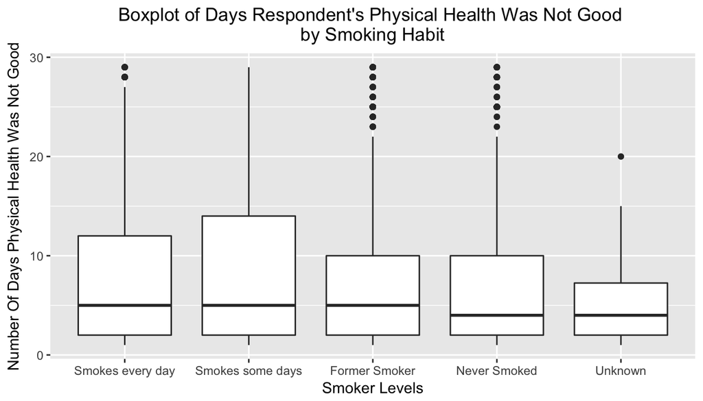

```r
SLEPTIM_HLTH <- allprep(SLEPTIM2, PHYSHLTH)

no0_dat3 <- analytic %>% filter(PHYSHLTH !=30 )
ggplot(no0_dat3, aes(y = PHYSHLTH, x=X_SMOKER3_f),fill=X_SMOKER3_f ) +
    geom_boxplot(position="dodge") +
    scale_fill_manual(values = heat_hcl(6, h = c(20,-80), l = c(75,40), c =c(40,80), power = 1)) +
    labs(title = "Boxplot of Days Respondent's Physical Health Was Not Good \n by Smoking Habit ", fill = "Respondent's Smoking Habit",x = "Smoker Levels", y = "Number Of Days Physical Health Was Not Good") +
    theme(plot.title = element_text(hjust = 0.5))
```

```r
# Change the point size, and shape
```

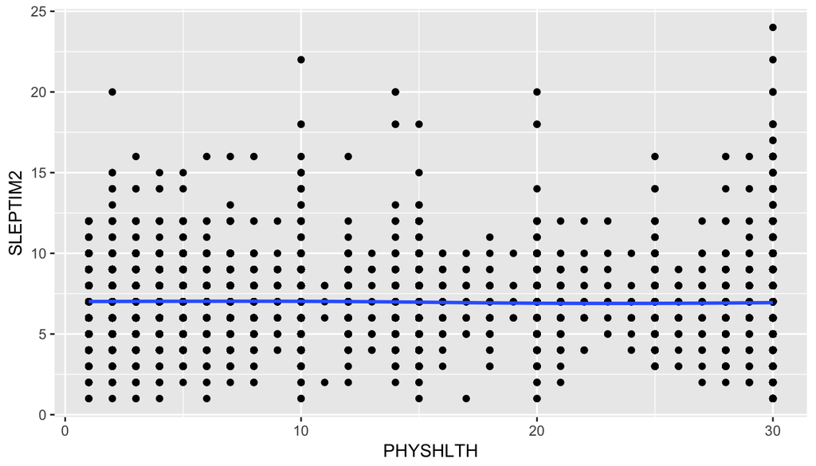

```r
ggplot(SLEPTIM_HLTH, aes(x=PHYSHLTH , y=SLEPTIM2)) + geom_point() + geom_smooth()
```

```r
# Change the point size, and shape
```